# Reporte 2

Jesús Cristóbal Salinas Villanueva

2022-10-17

**a) El alumno realizará el análisis descriptivo por variable, incluyendo medidas descriptivas, tablas de frecuencia y graficas tales como histogramas y boxplot.**

**Activo**

```r
library(readxl)
Tarea_4_BD <- read_excel("~/MCD Estadistica/Estadistica/Tarea 4 BD.xlsx")


#Activo
```

Mínimo, Q1, Q2=Mediana, Media, Q3, Máximo

```r
summary(Tarea_4_BD$activo)
```

```
##    Min. 1st Qu.  Median    Mean 3rd Qu.    Max.
##   97313  109092  133111  128492  141653  164341
```

Rango

```r
max(Tarea_4_BD$activo)-min(Tarea_4_BD$activo)
```

```
## [1] 67028.48
```

Varianza

```r
var(Tarea_4_BD$activo)
```

```
## [1] 402948285
```

Desviación estándar

```r
sd(Tarea_4_BD$activo)
```

```
## [1] 20073.57
```

Tabla de frecuencia

```r
clases_activo <- cut(Tarea_4_BD$activo, breaks=nclass.Sturges(Tarea_4_BD$activo))#clases
Freq <- as.data.frame(table(clases_activo))#frecuencuas
activo <- transform(Freq, CumFreq = cumsum(Freq), Rel = prop.table(Freq), CumRel=cumsum(prop.table(Freq)))#tabla
activo
```

```
##         clases_activo Freq CumFreq        Rel    CumRel
## 1 (9.72e+04,1.07e+05]   10      10 0.16393443 0.1639344
## 2 (1.07e+05,1.16e+05]   11      21 0.18032787 0.3442623
## 3 (1.16e+05,1.26e+05]    4      25 0.06557377 0.4098361
## 4 (1.26e+05,1.36e+05]   10      35 0.16393443 0.5737705
## 5 (1.36e+05,1.45e+05]   15      50 0.24590164 0.8196721
## 6 (1.45e+05,1.55e+05]    4      54 0.06557377 0.8852459
## 7 (1.55e+05,1.64e+05]    7      61 0.11475410 1.0000000
```

Histograma y boxplot

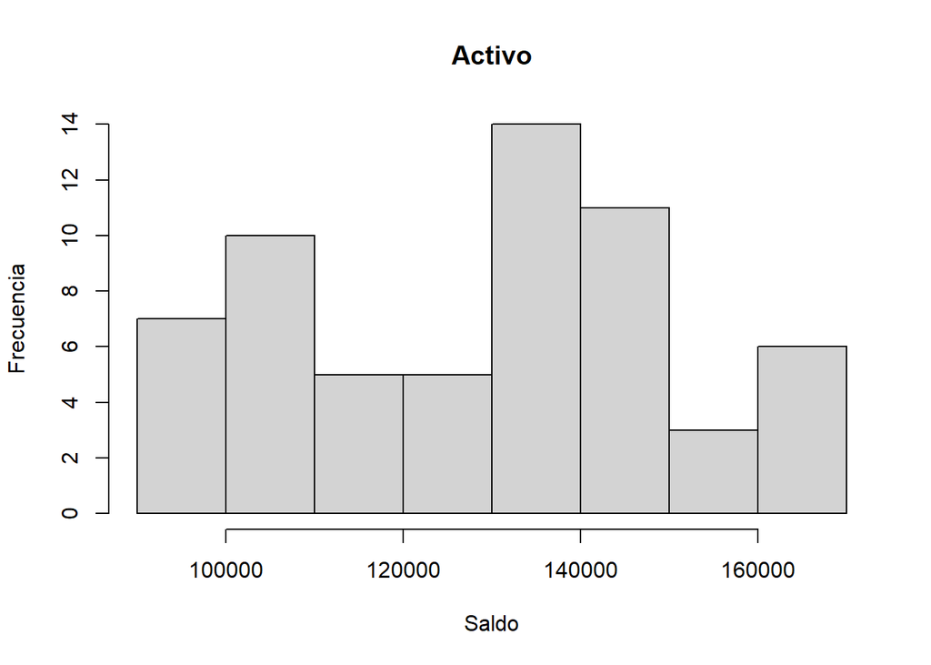

```r
hist(x= Tarea_4_BD$activo,main = "Activo", xlab = "Saldo", ylab = "Frecuencia")
```

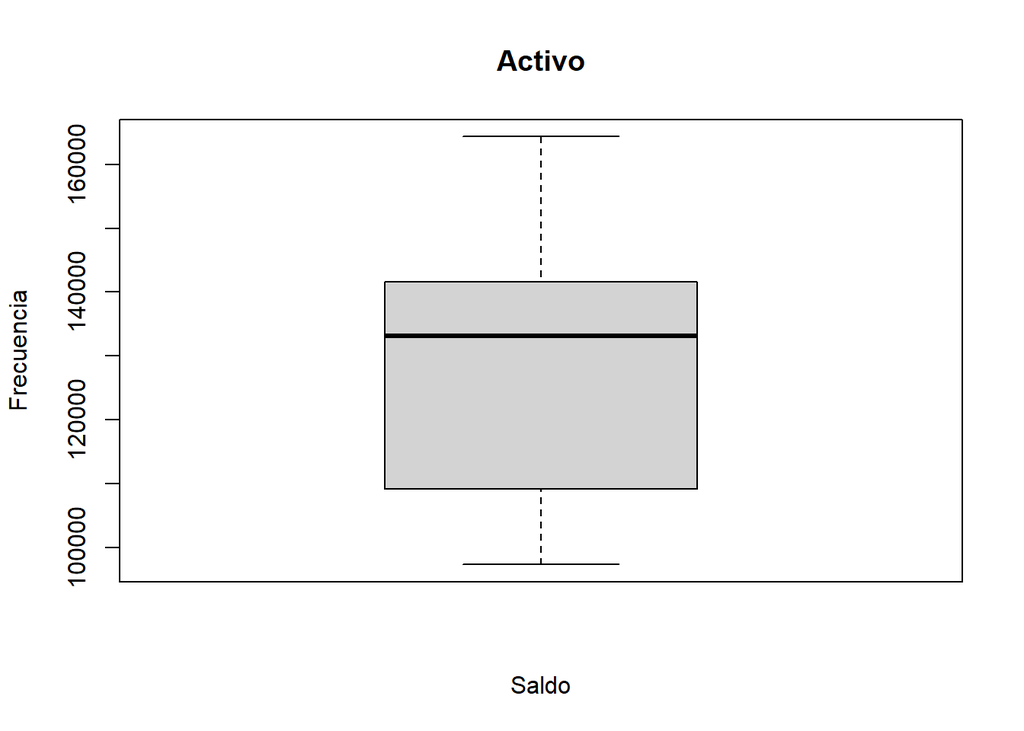

```r
boxplot(Tarea_4_BD$activo,main = "Activo", xlab = "Saldo", ylab = "Frecuencia")
```

```r
knitr::opts_chunk$set(echo = TRUE)
```

**Vista**

Mínimo, Q1, Q2=Mediana, Media, Q3, Máximo

```r
summary(Tarea_4_BD$vista)
```

```
##    Min. 1st Qu.  Median    Mean 3rd Qu.    Max.
##   28340   32719   37702   40771   46529   63036
```

Rango

```r
max(Tarea_4_BD$vista)-min(Tarea_4_BD$vista)
```

```
## [1] 34695.57
```

Varianza

```r
var(Tarea_4_BD$vista)
```

```
## [1] 105343932
```

Desviación estándar

```r
sd(Tarea_4_BD$vista)
```

```
## [1] 10263.72
```

Tabla de frecuencia

```r
clases_vista <- cut(Tarea_4_BD$vista, breaks=nclass.Sturges(Tarea_4_BD$vista))#clases
Freq <- as.data.frame(table(clases_vista))#frecuencuas
vista <- transform(Freq, CumFreq = cumsum(Freq), Rel = prop.table(Freq), CumRel=cumsum(prop.table(Freq)))#tabla
vista
```

```
##          clases_vista Freq CumFreq        Rel    CumRel
## 1 (2.83e+04,3.33e+04]   20      20 0.32786885 0.3278689
## 2 (3.33e+04,3.83e+04]   13      33 0.21311475 0.5409836
## 3 (3.83e+04,4.32e+04]    6      39 0.09836066 0.6393443
## 4 (4.32e+04,4.82e+04]    8      47 0.13114754 0.7704918
## 5 (4.82e+04,5.31e+04]    4      51 0.06557377 0.8360656
## 6 (5.31e+04,5.81e+04]    3      54 0.04918033 0.8852459
## 7 (5.81e+04,6.31e+04]    7      61 0.11475410 1.0000000
```

Histograma y boxplot

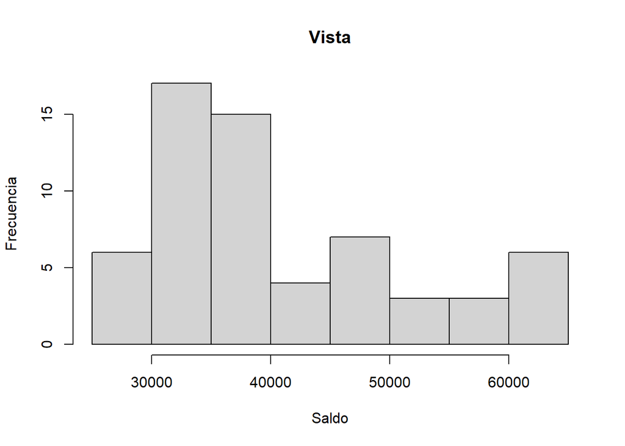

```r
hist(x= Tarea_4_BD$vista,main = "Vista", xlab = "Saldo", ylab = "Frecuencia")
```

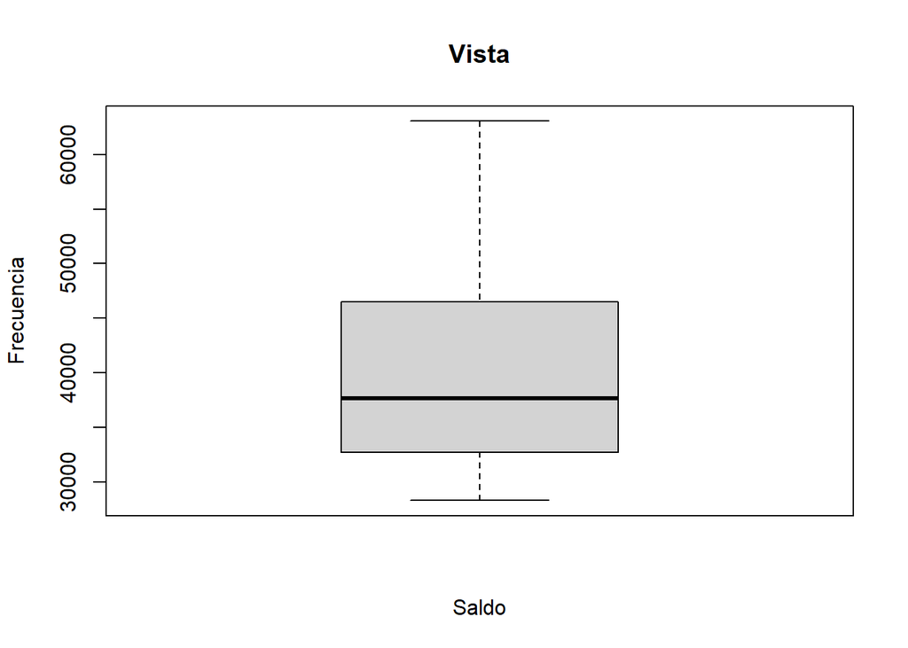

```r
boxplot(Tarea_4_BD$vista,main = "Vista", xlab = "Saldo", ylab = "Frecuencia")
```

```r
knitr::opts_chunk$set(echo = TRUE)
```

**Plazo**

Mínimo, Q1, Q2=Mediana, Media, Q3, Máximo

```r
summary(Tarea_4_BD$plazo)
```

```
##    Min. 1st Qu.  Median    Mean 3rd Qu.    Max.
##   35428   44615   48827   49155   54369   60584
```

Rango

```r
max(Tarea_4_BD$plazo)-min(Tarea_4_BD$plazo)
```

```
## [1] 25155.92
```

Varianza

```r
var(Tarea_4_BD$plazo)
```

```
## [1] 50230518
```

Desviación estándar

```r
sd(Tarea_4_BD$plazo)
```

```
## [1] 7087.349
```

Tabla de frecuencia

```r
clases_plazo <- cut(Tarea_4_BD$plazo, breaks=nclass.Sturges(Tarea_4_BD$plazo))#clases
Freq <- as.data.frame(table(clases_plazo))#frecuencuas
plazo <- transform(Freq, CumFreq = cumsum(Freq), Rel = prop.table(Freq), CumRel=cumsum(prop.table(Freq)))#tabla
plazo
```

```
##          clases_plazo Freq CumFreq        Rel    CumRel
## 1  (3.54e+04,3.9e+04]    7       7 0.11475410 0.1147541
## 2  (3.9e+04,4.26e+04]    4      11 0.06557377 0.1803279
## 3 (4.26e+04,4.62e+04]   10      21 0.16393443 0.3442623
## 4 (4.62e+04,4.98e+04]   12      33 0.19672131 0.5409836
## 5 (4.98e+04,5.34e+04]   11      44 0.18032787 0.7213115
## 6  (5.34e+04,5.7e+04]    4      48 0.06557377 0.7868852
## 7  (5.7e+04,6.06e+04]   13      61 0.21311475 1.0000000
```

Histograma y boxplot

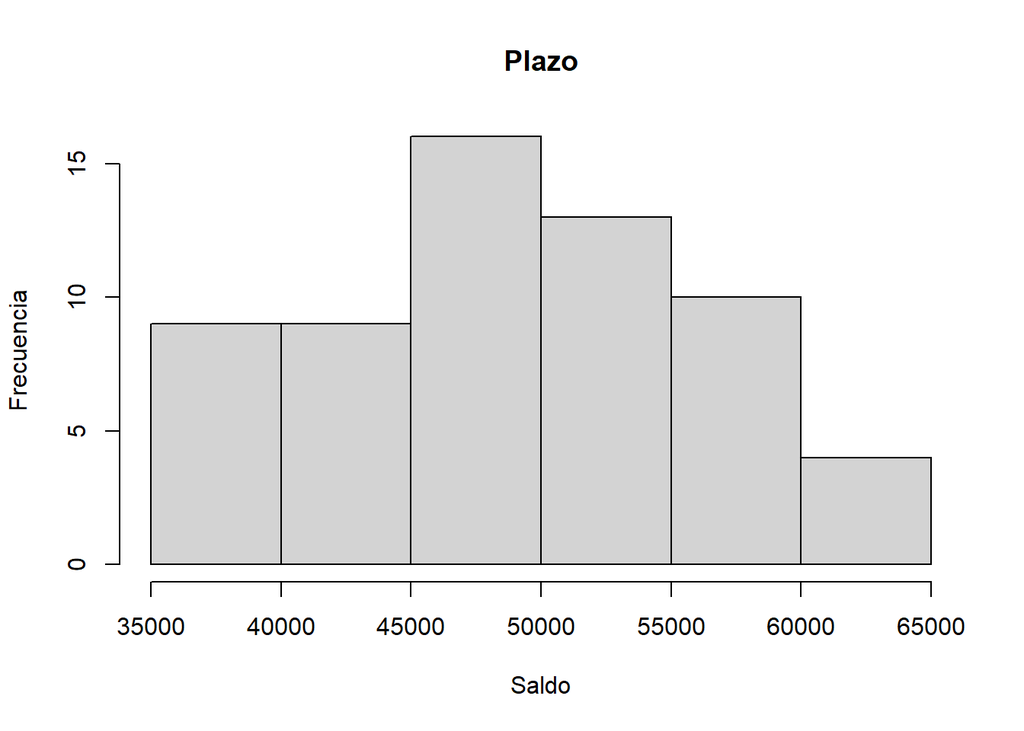

```r
hist(x= Tarea_4_BD$plazo,main = "Plazo", xlab = "Saldo", ylab = "Frecuencia")
```

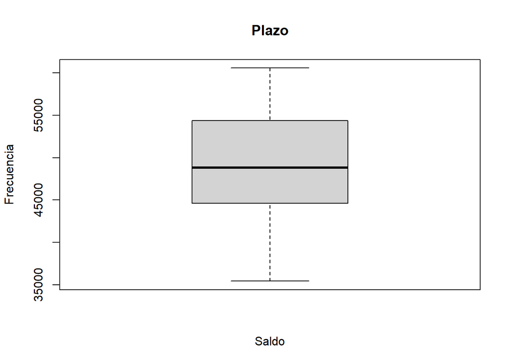

```r
boxplot(Tarea_4_BD$plazo,main = "Plazo", xlab = "Saldo", ylab = "Frecuencia")
```

```r
knitr::opts_chunk$set(echo = TRUE)
```

**Prestamos interbancarios**

Mínimo, Q1, Q2=Mediana, Media, Q3, Máximo

```r
summary(Tarea_4_BD$prestamos_interbancarios)
```

```
##    Min. 1st Qu.  Median    Mean 3rd Qu.    Max.
##    4334    5417    5812    5910    6298    8319
```

Rango

```r
max(Tarea_4_BD$prestamos_interbancarios)-min(Tarea_4_BD$prestamos_interbancarios)
```

```
## [1] 3984.778
```

Varianza

```r
var(Tarea_4_BD$prestamos_interbancarios)
```

```
## [1] 943593.1
```

Desviación estándar

```r
sd(Tarea_4_BD$prestamos_interbancarios)
```

```
## [1] 971.3872
```

Tabla de frecuencia

```r
clases_prestamos_interbancarios <- cut(Tarea_4_BD$prestamos_interbancarios, breaks=nclass.Sturges(Tarea_4_BD$prestamos_interbancarios))#clases
Freq <- as.data.frame(table(clases_prestamos_interbancarios))#frecuencuas
prestamos_interbancarios <- transform(Freq, CumFreq = cumsum(Freq), Rel = prop.table(Freq), CumRel=cumsum(prop.table(Freq)))#tabla
prestamos_interbancarios
```

```
##   clases_prestamos_interbancarios Freq CumFreq        Rel    CumRel
## 1              (4.33e+03,4.9e+03]   10      10 0.16393443 0.1639344
## 2              (4.9e+03,5.47e+03]    9      19 0.14754098 0.3114754
## 3             (5.47e+03,6.04e+03]   16      35 0.26229508 0.5737705
## 4             (6.04e+03,6.61e+03]   17      52 0.27868852 0.8524590
## 5             (6.61e+03,7.18e+03]    2      54 0.03278689 0.8852459
## 6             (7.18e+03,7.75e+03]    1      55 0.01639344 0.9016393
## 7             (7.75e+03,8.32e+03]    6      61 0.09836066 1.0000000
```

Histograma y boxplot

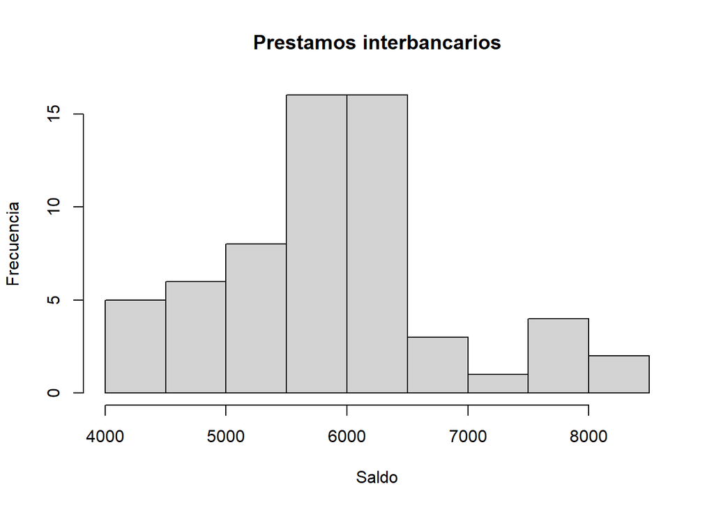

```r
hist(x= Tarea_4_BD$prestamos_interbancarios,main = "Prestamos interbancarios", xlab = "Saldo", ylab = "Frecuencia")
```

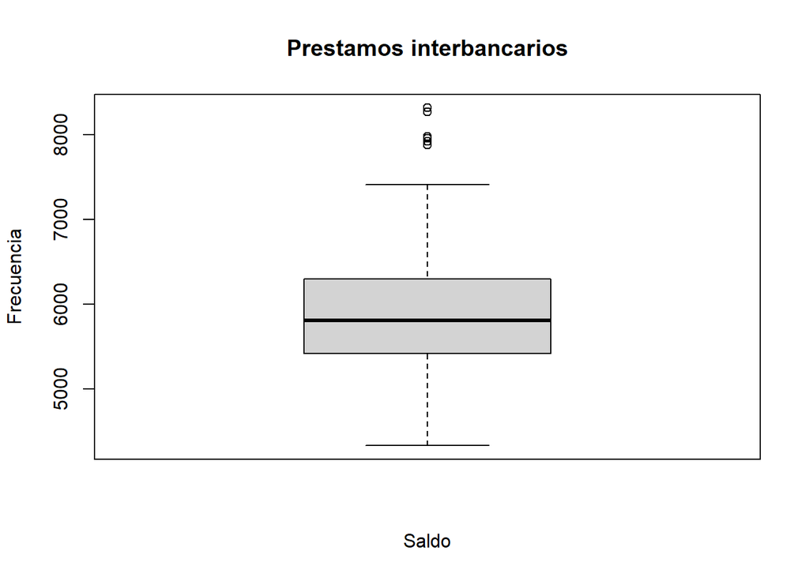

```r
boxplot(Tarea_4_BD$prestamos_interbancarios,main = "Prestamos interbancarios", xlab = "Saldo", ylab = "Frecuencia")
```

```r
knitr::opts_chunk$set(echo = TRUE)
```

**Sucursales**

Mínimo, Q1, Q2=Mediana, Media, Q3, Máximo

```r
summary(Tarea_4_BD$sucursales)
```

```
##    Min. 1st Qu.  Median    Mean 3rd Qu.    Max.
##   147.0   150.0   159.0   157.9   164.0   173.0
```

Rango

```r
max(Tarea_4_BD$sucursales)-min(Tarea_4_BD$sucursales)
```

```
## [1] 26
```

Varianza

```r
var(Tarea_4_BD$sucursales)
```

```
## [1] 50.20984
```

Desviación estándar

```r
sd(Tarea_4_BD$sucursales)
```

```
## [1] 7.08589
```

Tabla de frecuencia

```r
clases_sucursales <- cut(Tarea_4_BD$sucursales, breaks=nclass.Sturges(Tarea_4_BD$sucursales))#clases
Freq <- as.data.frame(table(clases_sucursales))#frecuencuas
sucursales <- transform(Freq, CumFreq = cumsum(Freq), Rel = prop.table(Freq), CumRel=cumsum(prop.table(Freq)))#tabla
sucursales
```

```
##   clases_sucursales Freq CumFreq        Rel    CumRel
## 1         (147,151]   21      21 0.34426230 0.3442623
## 2         (151,154]    3      24 0.04918033 0.3934426
## 3         (154,158]    5      29 0.08196721 0.4754098
## 4         (158,162]   10      39 0.16393443 0.6393443
## 5         (162,166]    9      48 0.14754098 0.7868852
## 6         (166,169]   11      59 0.18032787 0.9672131
## 7         (169,173]    2      61 0.03278689 1.0000000
```

Histograma y boxplot

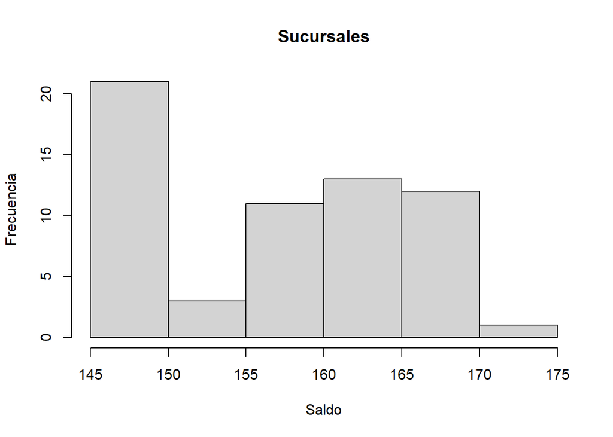

```r
hist(x= Tarea_4_BD$sucursales,main = "Sucursales", xlab = "Saldo", ylab = "Frecuencia")
```

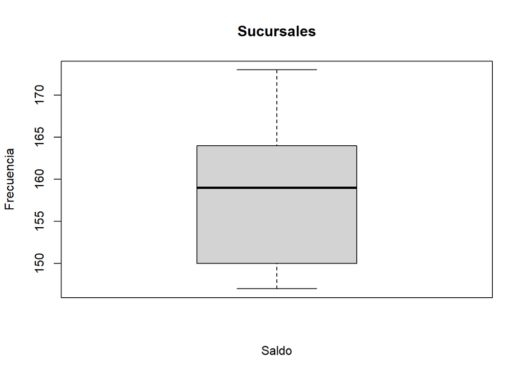

```r
boxplot(Tarea_4_BD$sucursales,main = "Sucursales", xlab = "Saldo", ylab = "Frecuencia")
```

```r
knitr::opts_chunk$set(echo = TRUE)
```

**Cajeros**

Mínimo, Q1, Q2=Mediana, Media, Q3, Máximo

```r
summary(Tarea_4_BD$cajeros)
```

```
##    Min. 1st Qu.  Median    Mean 3rd Qu.    Max.
##   271.0   283.0   303.0   305.9   326.0   378.0
```

Rango

```r
max(Tarea_4_BD$cajeros)-min(Tarea_4_BD$cajeros)
```

```
## [1] 107
```

Varianza

```r
var(Tarea_4_BD$cajeros)
```

```
## [1] 728.0956
```

Desviación estándar

```r
sd(Tarea_4_BD$cajeros)
```

```
## [1] 26.98325
```

Tabla de frecuencia

```r
clases_cajeros <- cut(Tarea_4_BD$cajeros, breaks=nclass.Sturges(Tarea_4_BD$cajeros))#clases
Freq <- as.data.frame(table(clases_cajeros))#frecuencuas
cajeros <- transform(Freq, CumFreq = cumsum(Freq), Rel = prop.table(Freq), CumRel=cumsum(prop.table(Freq)))#tabla
cajeros
```

```
##   clases_cajeros Freq CumFreq        Rel    CumRel
## 1      (271,286]   20      20 0.32786885 0.3278689
## 2      (286,302]    9      29 0.14754098 0.4754098
## 3      (302,317]   16      45 0.26229508 0.7377049
## 4      (317,332]    4      49 0.06557377 0.8032787
## 5      (332,347]    6      55 0.09836066 0.9016393
## 6      (347,363]    4      59 0.06557377 0.9672131
## 7      (363,378]    2      61 0.03278689 1.0000000
```

Histograma y boxplot

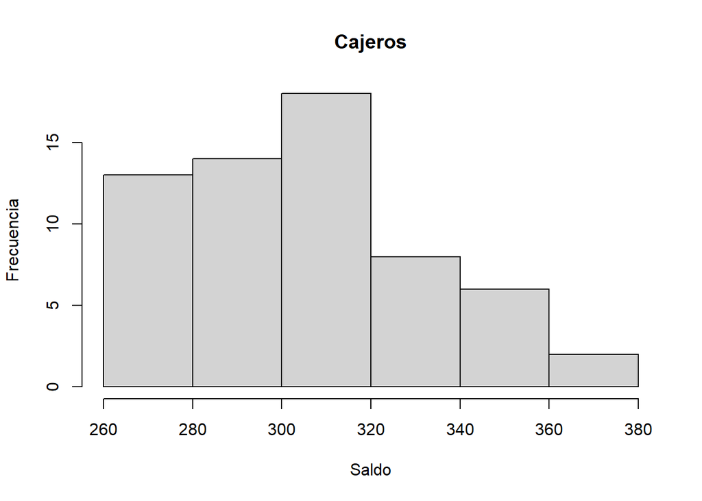

```r
hist(x= Tarea_4_BD$cajeros,main = "Cajeros", xlab = "Saldo", ylab = "Frecuencia")
```

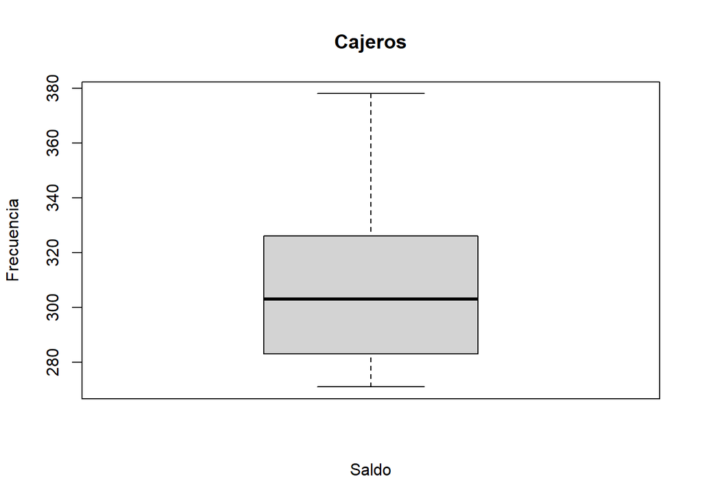

```r
boxplot(Tarea_4_BD$cajeros,main = "Cajeros", xlab = "Saldo", ylab = "Frecuencia")
```

```r
knitr::opts_chunk$set(echo = TRUE)
```

**Tarjetas**

Mínimo, Q1, Q2=Mediana, Media, Q3, Máximo

```r
summary(Tarea_4_BD$tarjetas)
```

```
##    Min. 1st Qu.  Median    Mean 3rd Qu.    Max.
##   75627  108793  129247  140139  182882  229946
```

Rango

```r
max(Tarea_4_BD$tarjetas)-min(Tarea_4_BD$tarjetas)
```

```
## [1] 154319
```

Varianza

```r
var(Tarea_4_BD$tarjetas)
```

```
## [1] 1810773101
```

Desviación estándar

```r
sd(Tarea_4_BD$tarjetas)
```

```
## [1] 42553.18
```

Tabla de frecuencia

```r
clases_tarjetas <- cut(Tarea_4_BD$tarjetas, breaks=nclass.Sturges(Tarea_4_BD$tarjetas))#clases
Freq <- as.data.frame(table(clases_tarjetas))#frecuencuas
tarjetas <- transform(Freq, CumFreq = cumsum(Freq), Rel = prop.table(Freq), CumRel=cumsum(prop.table(Freq)))#tabla
tarjetas
```

```
##       clases_tarjetas Freq CumFreq        Rel    CumRel
## 1 (7.55e+04,9.77e+04]    9       9 0.14754098 0.1475410
## 2  (9.77e+04,1.2e+05]   13      22 0.21311475 0.3606557
## 3  (1.2e+05,1.42e+05]   16      38 0.26229508 0.6229508
## 4 (1.42e+05,1.64e+05]    1      39 0.01639344 0.6393443
## 5 (1.64e+05,1.86e+05]   13      52 0.21311475 0.8524590
## 6 (1.86e+05,2.08e+05]    5      57 0.08196721 0.9344262
## 7  (2.08e+05,2.3e+05]    4      61 0.06557377 1.0000000
```

Histograma y boxplot

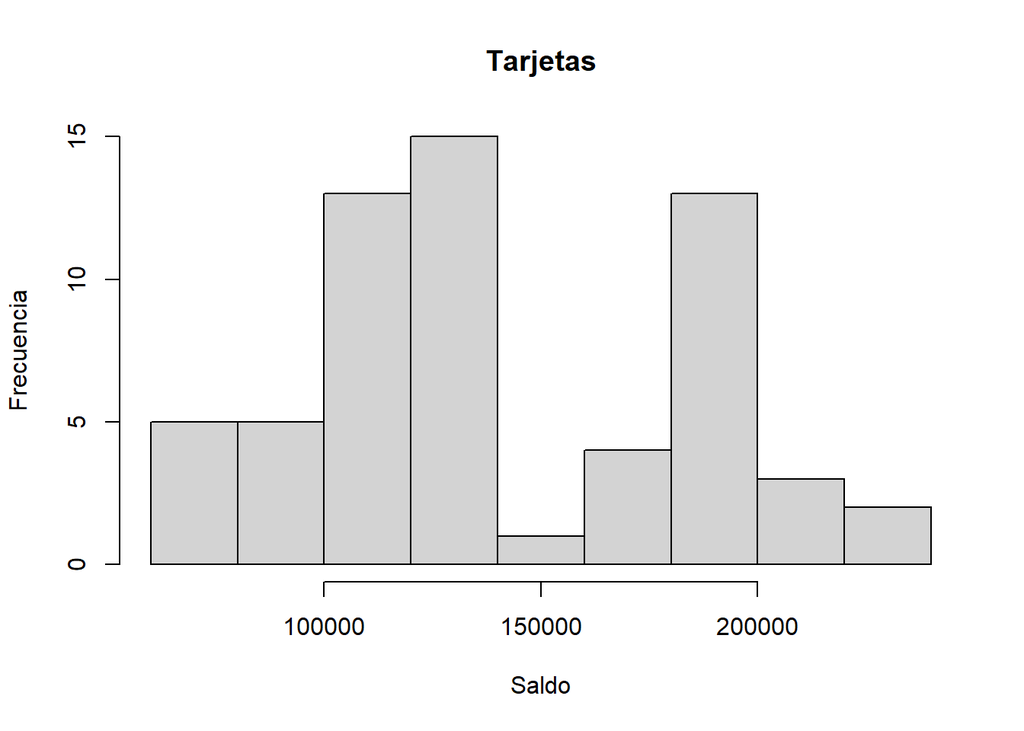

```r
hist(x= Tarea_4_BD$tarjetas,main = "Tarjetas", xlab = "Saldo", ylab = "Frecuencia")
```

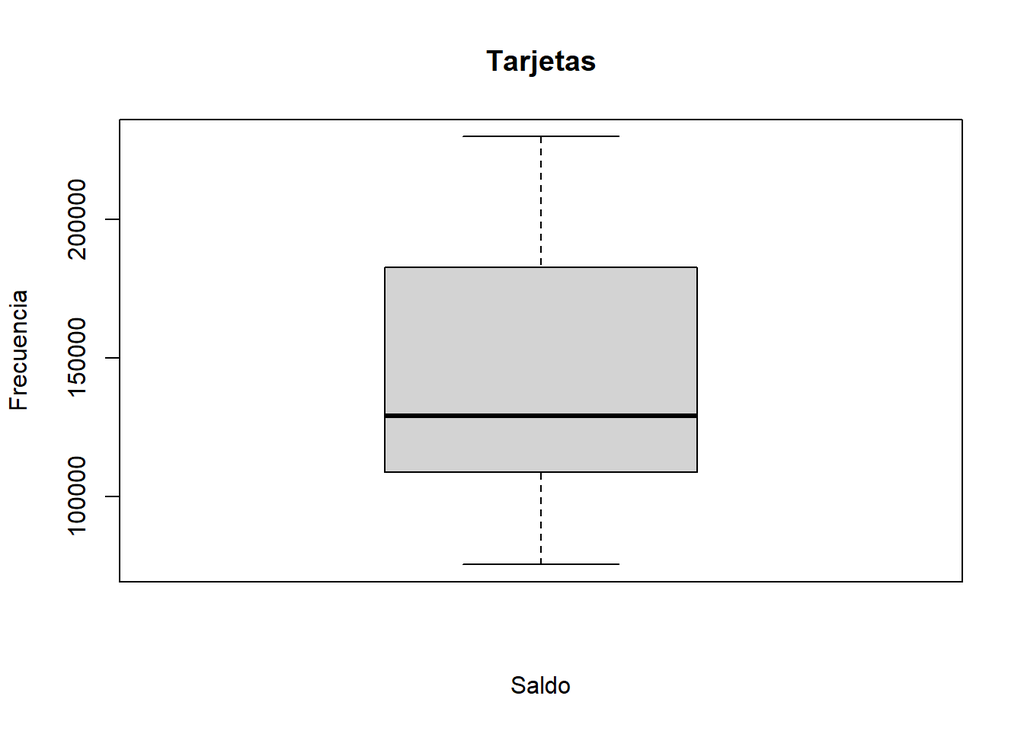

```r
boxplot(Tarea_4_BD$tarjetas,main = "Tarjetas", xlab = "Saldo", ylab = "Frecuencia")
```

```r
knitr::opts_chunk$set(echo = TRUE)
```

**b) El alumno identificará, a manera de sospecha, apoyado en los resultados anteriores una distribución asociada a la variable**

Histograma y boxplot

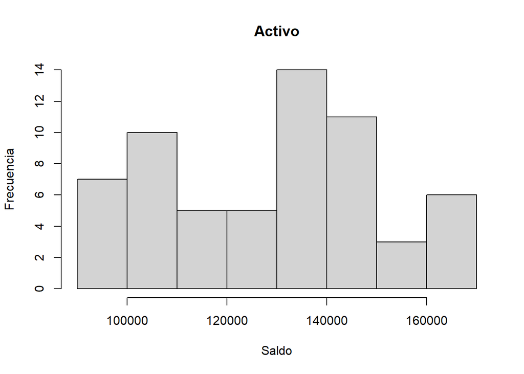

```r
hist(x= Tarea_4_BD$activo,main = "Activo", xlab = "Saldo", ylab = "Frecuencia")
```

```r
knitr::opts_chunk$set(echo = TRUE)
```

[figure not shown]

**WEIBULL**

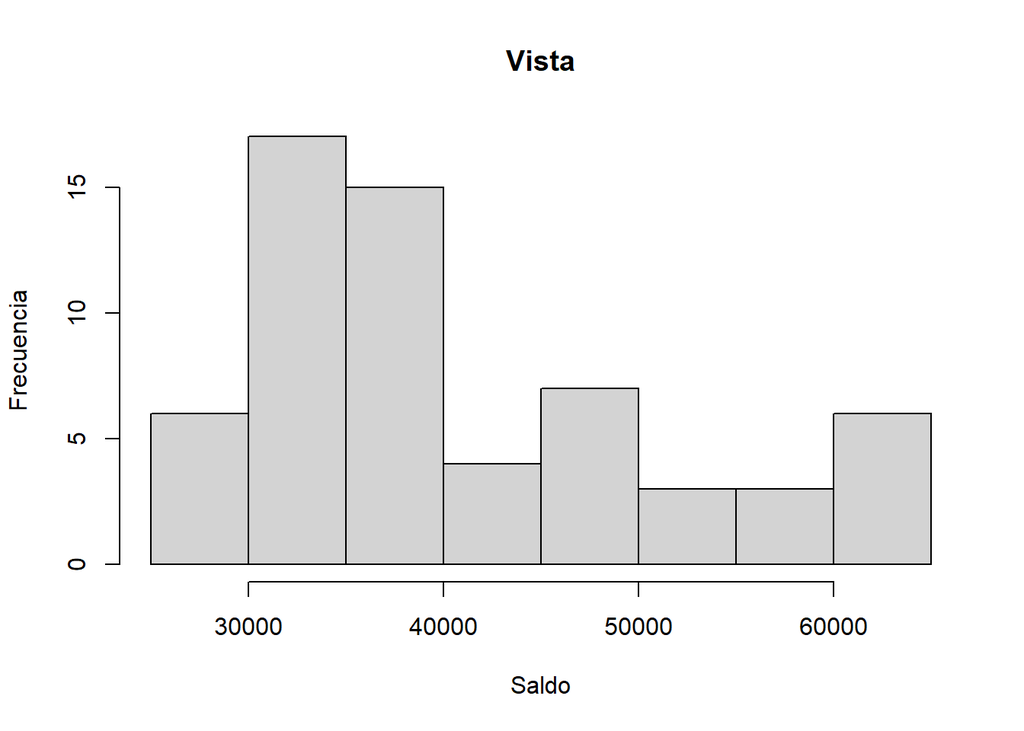

```r
hist(x= Tarea_4_BD$vista,main = "Vista", xlab = "Saldo", ylab = "Frecuencia")
```

```r
knitr::opts_chunk$set(echo = TRUE)
```

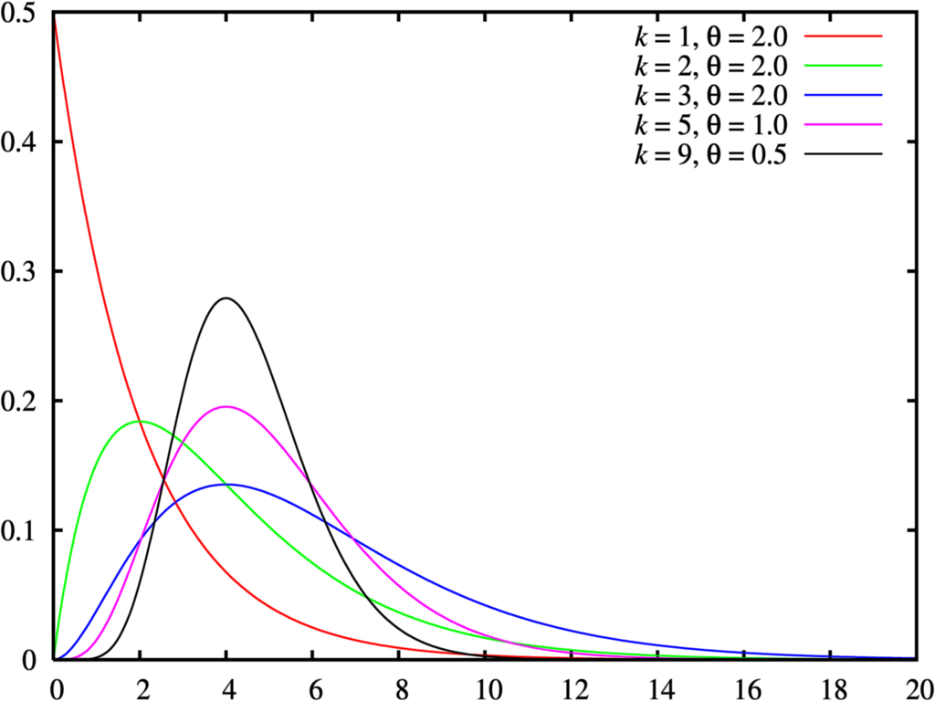

**GAMMA**

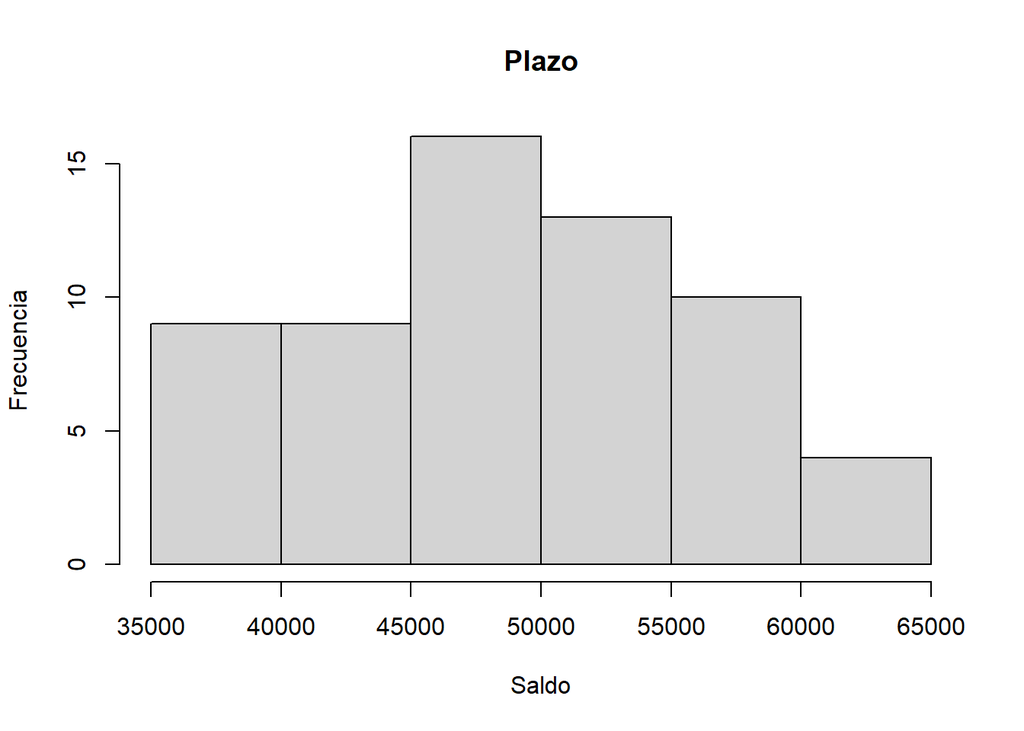

```r
hist(x= Tarea_4_BD$plazo,main = "Plazo", xlab = "Saldo", ylab = "Frecuencia")
```

```r
knitr::opts_chunk$set(echo = TRUE)
```

**Normal**

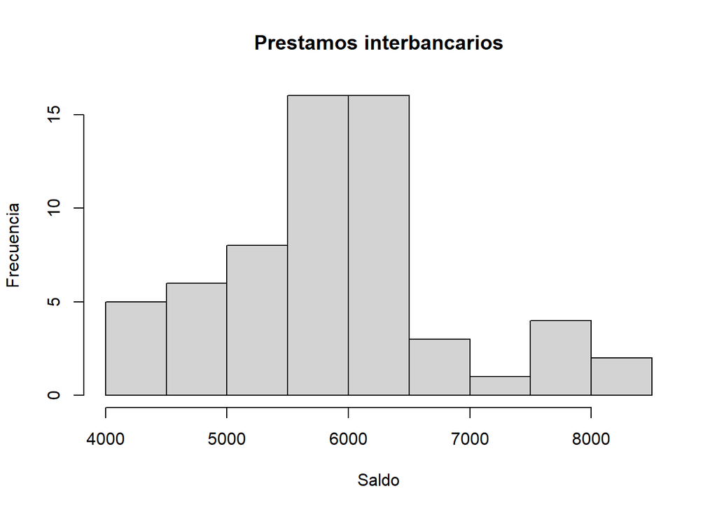

```r
hist(x= Tarea_4_BD$prestamos_interbancarios,main = "Prestamos interbancarios", xlab = "Saldo", ylab = "Frecuencia")
```

```r
knitr::opts_chunk$set(echo = TRUE)
```

**Normal**

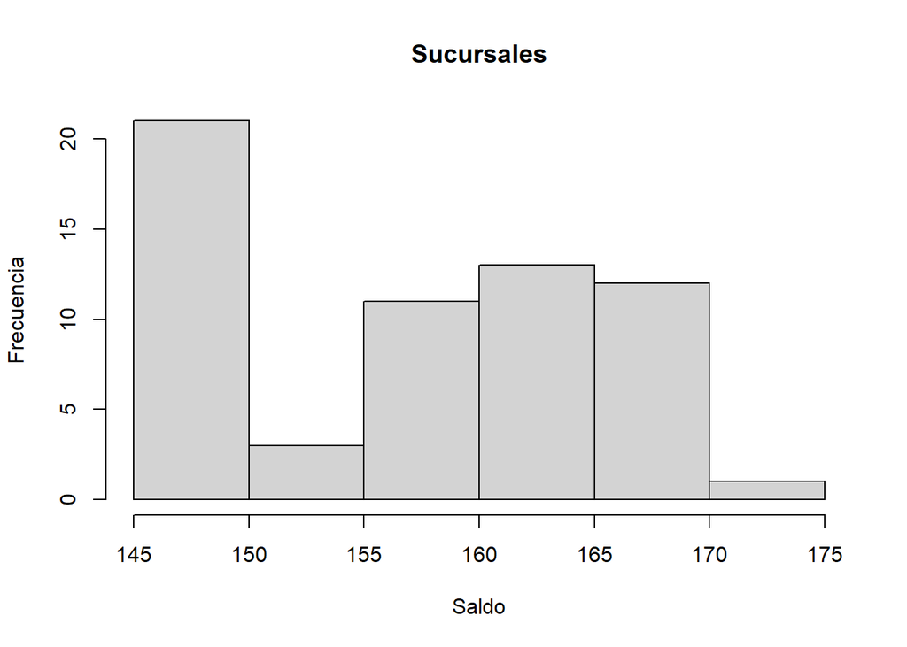

```r
hist(x= Tarea_4_BD$sucursales,main = "Sucursales", xlab = "Saldo", ylab = "Frecuencia")
```

```r
knitr::opts_chunk$set(echo = TRUE)
```

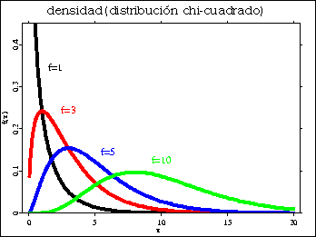

**Chi cuadrada**

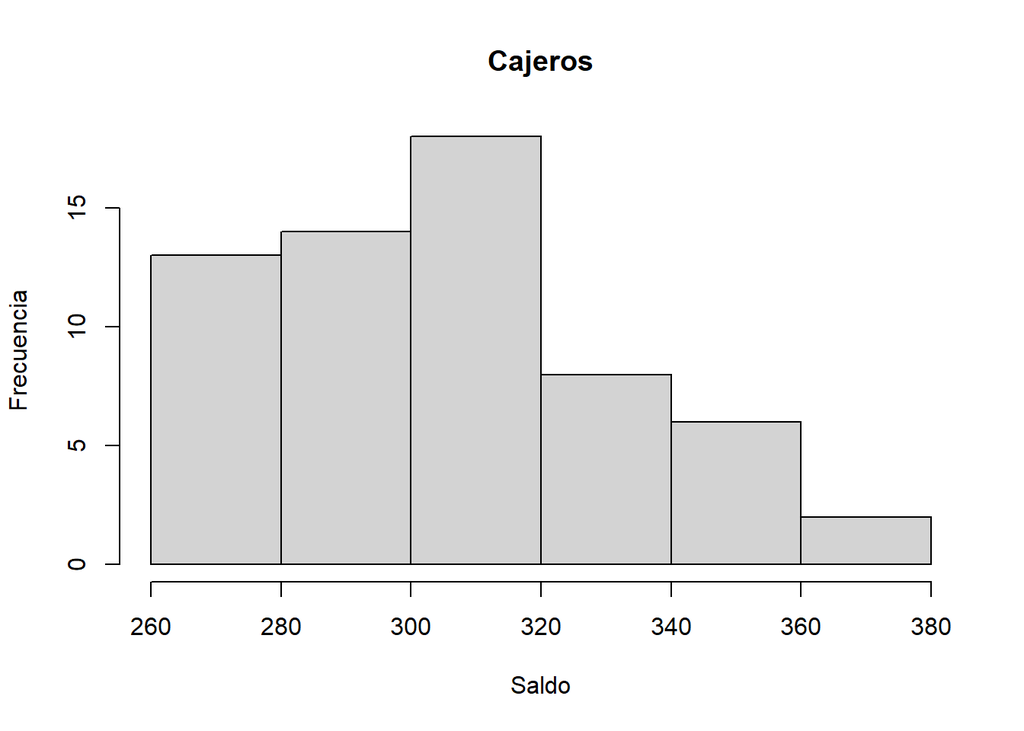

```r
hist(x= Tarea_4_BD$cajeros,main = "Cajeros", xlab = "Saldo", ylab = "Frecuencia")
```

```r
knitr::opts_chunk$set(echo = TRUE)
```

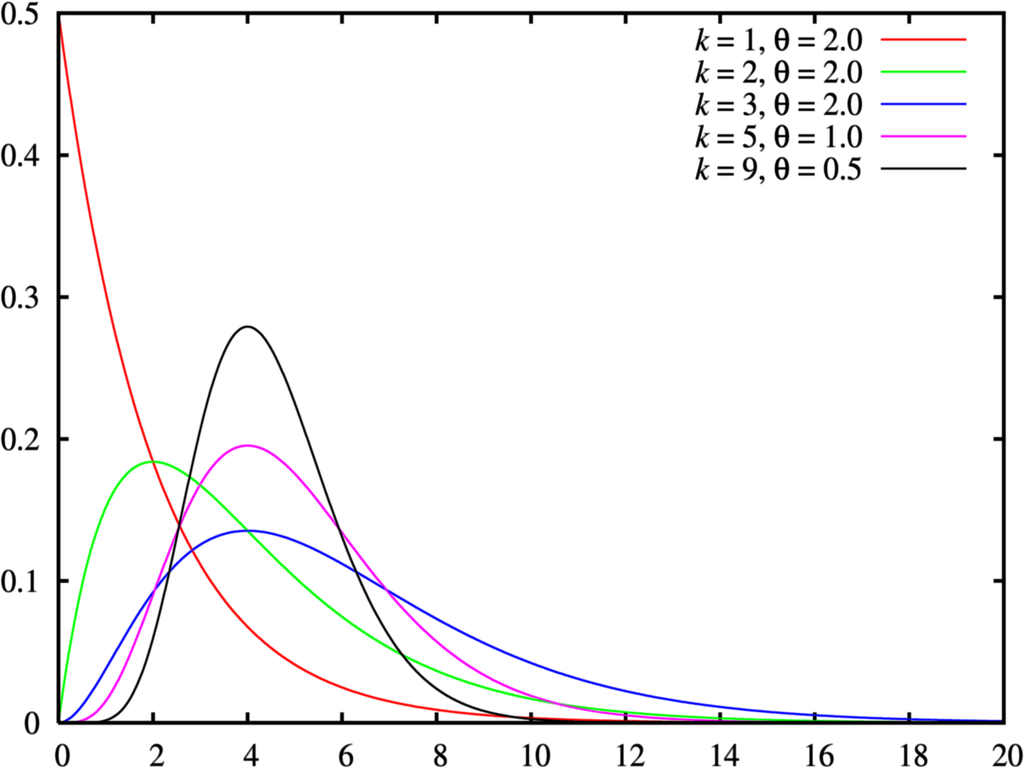

**GAMMA**

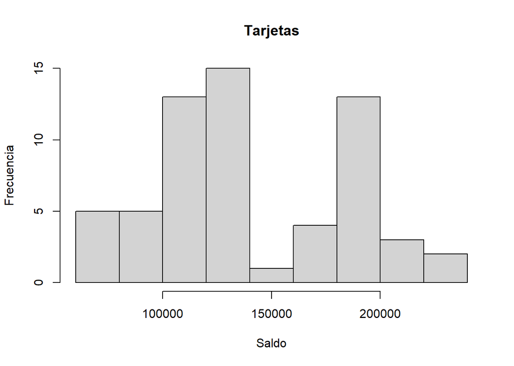

```r
hist(x= Tarea_4_BD$tarjetas,main = "Tarjetas", xlab = "Saldo", ylab = "Frecuencia")
```

```r
knitr::opts_chunk$set(echo = TRUE)
```

**Normal**

**c) El alumno realizará el planteamiento de problemáticas de interés que puedan resolverse mediante el cálculo de una probabilidad. Aquí se planteará el contexto de la problemática además de la probabilidad asociada.**

Estimar el saldo de la variable respuesta (activos) de la institución financiera de acuerdo con la información de las variables regresoras (vista, plazo, préstamos, sucursales, cajeros y tarjetas) y con esto, poder solventar las posibles brechas de liquidez que puedan traer las variaciones mensuales de estas variables.

A mayor saldo de vista, plazo y/o préstamos bancarios, se tendrá una mayor cantidad de depósitos en el banco, lo que implicaría una mayor salida de dinero en algún momento del mes, por lo tanto, se necesita tener la cantidad de activos mínima necesaria para en una posible salida de dinero, se pueda cubrir con el saldo de los activos.

Adicional a esto, una mayor cantidad de sucursales, tarjetas y cajeros, implica que la cantidad de clientes esta creciendo, al mismo tiempo que el saldo ya sea de vista, plazo o préstamos interbancarios, ya que el banco, esta aplicando una estrategia de negocio para poder atraerlos y ofrecerles distintos servicios y/o productos para que los clientes le depósiten su dinero.

Con el cálculo de la propabilidad de activos para el siguiente mes, el banco podría optimizar sus estrategias de negocio para atraer o no nuevos clientes o abrir nuevas sucursales, autorizar tarjetas o poner más cajeros, los cuales también generan un costo el cual se podría reducir y generar más beneficio.